# Introducción conceptual a los modelos lineales mixtos

- Mostrar todo el código
- Ocultar todo el código
- Ver el código fuente

Antes de los tutoriales de Winter (2013)

Autor/a

Filip Andras — CIMCYC, Universidad de Granada

Fecha de publicación

12 noviembre 2026

Resumen

Por qué hace falta un modelo mixto: el supuesto de independencia, las dependencias cruzadas y anidadas, y las dos soluciones, promediar o informar al modelo. Con `sleepstudy`: interceptos y pendientes variables en notación matemática y de R, qué estima el modelo de verdad, cómo leer la salida de `lme4`, la correlación entre interceptos y pendientes, qué pendientes incluir y la contracción hacia la media (*shrinkage*).

Este documento es la introducción conceptual a los modelos lineales mixtos, con un ejemplo de medidas repetidas que viene con `lme4`: `sleepstudy`.

# El supuesto de independencia

El Tutorial 1 terminaba en el supuesto más importante del modelo lineal, la independencia, que no se comprueba con un gráfico: **se decide en el diseño**. La pregunta es cuántas medidas aporta cada persona.

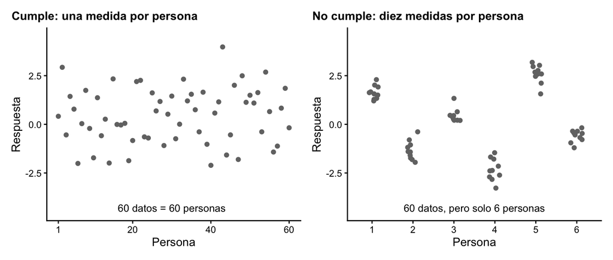

Una dependencia es cualquier conexión entre dos datos. La más común: medidas repetidas de una misma persona. Las medidas de una misma persona se parecen más entre sí que las de personas distintas, y eso se puede decir con los residuos: si la persona A responde en general más rápido que la persona B, todos los residuos de A van juntos, y todos los de B también.

Si el modelo no sabe de esas dependencias, es como si la muestra fuera mayor de lo que es, y los falsos positivos se disparan muy por encima del 5 %.

## Dependencias cruzadas y anidadas

Las dependencias vienen en dos formas. En un diseño **cruzado** (*crossed*), cada nivel de un factor se combina con cada nivel del otro: cada participante responde a todas las palabras, y cada palabra la ven todos los participantes. Hay dos fuentes de dependencia a la vez, la persona y la palabra. En un diseño **anidado** (*nested*), cada unidad pertenece a una sola unidad mayor: cada cría es de una sola camada, cada paciente de un solo terapeuta, cada alumno de una sola aula.

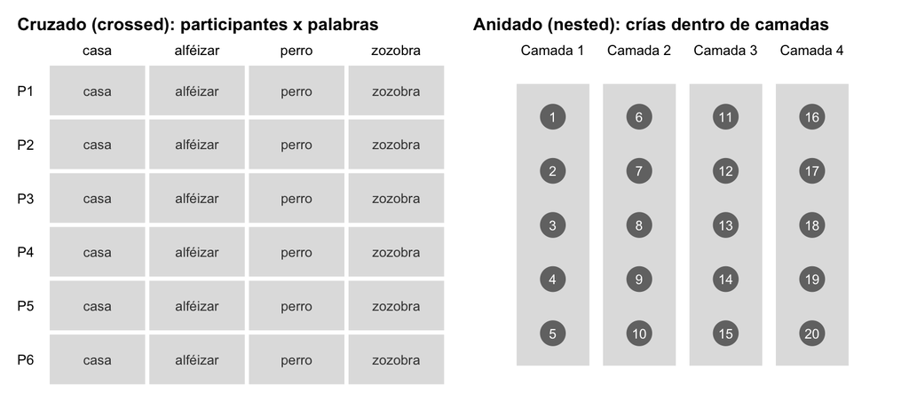

En `lme4`, el cruzado es `(1|participante) + (1|palabra)`. El anidado, `(1|camada)`, y si hay varias medidas por cría, `(1|camada/cria)`.

Ejemplos de cada forma:

- **Psicología clínica.** Pacientes de distintas clínicas u hospitales, cada uno con sus terapeutas: pacientes dentro de terapeutas, y terapeutas dentro de centros. Anidado, en dos niveles.
- **Psicobiología.** Crías dentro de camadas: anidado.
- **Psicolingüística.** Participantes y palabras o frases, cruzado.
- **Psicología experimental.** Participantes que responden a un mismo conjunto de estímulos: caras, o imágenes de alimentos en la investigación sobre trastornos de la conducta alimentaria. Cruzado: cada persona ve todos los estímulos y cada estímulo lo ven todas las personas.

# Primera solución: promediar

Si cada persona aporta varios datos, se reduce cada persona a su media y se analizan las medias. Funciona, pero pierde información. La variación entre las medidas de cada persona desaparece del análisis, el modelo subestima cuánta variación hay y tiene menos con que inferir.

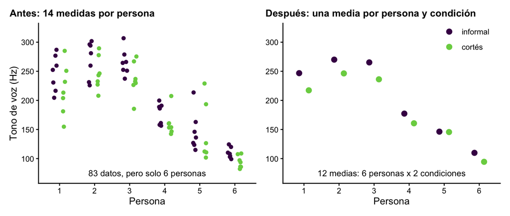

Es lo que se hacía antes: un análisis por sujetos, promediando los ítems, y otro por ítems, promediando los sujetos (Clark, 1973; Baayen, Davidson y Bates, 2008). El modelo mixto usa todos los datos y tiene en cuenta las dos fuentes de variación a la vez.

**NotaEn este caso, promediar no basta**

Aunque los datos estén promediados, cada persona sigue aportando dos medias, una por condición, y las dos vienen de la misma voz. Para comparar las condiciones hay que seguir usando una prueba *t* pareada o un ANOVA de medidas repetidas, que tienen en cuenta de quién es cada media. Conceptualmente, eso ya es un modelo mixto: la prueba *t* pareada equivale a un modelo con la condición como efecto fijo y un intercepto variable por persona.

# Segunda solución: informar al modelo sobre las dependencias

El modelo mixto permite meter en el análisis los grupos de datos que no son independientes: se le dice qué dependencias hay y él estima e infiere teniendo eso en cuenta. La herramienta son los **efectos aleatorios**, en concreto los **interceptos variables** y las **pendientes variables**.

Los **efectos fijos** no tienen nada de especial: son los predictores de siempre, y hasta ahora todos los modelos eran solo de efectos fijos. Lo que cambia es que la relación entre $y$ y un efecto fijo puede variar por individuo. La mezcla de los dos es lo que hace “mixto” al modelo.

> El ejemplo: `sleepstudy` (Belenky et al., 2003), el conjunto de datos que trae `lme4`. Dieciocho personas durmieron tres horas por noche durante nueve días, y cada día se midió su tiempo medio de reacción. Cada persona aporta diez medidas, una por día. Con la falta de sueño las reacciones se vuelven más lentas, pero no a todos por igual: a algunos apenas les afecta.

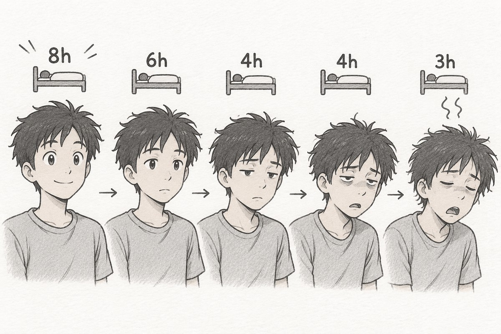

`Tiempo de reacción ~ Falta de sueño`

**NotaLo importante: la idiosincrasia**

Los efectos fijos son la parte que entendemos. Los aleatorios recogen lo idiosincrásico, lo propio de cada participante, que a menudo no nos interesa en sí pero afecta a todas sus medidas: su tiempo de reacción de base y cuánto le afecta la falta de sueño.

**Generalizar más allá de la muestra.** Estos 18 participantes son una muestra de todos los posibles. El modelo trata sus diferencias como aleatorias para poder hablar de personas en general, no solo de estas.

Tres de los dieciocho participantes:

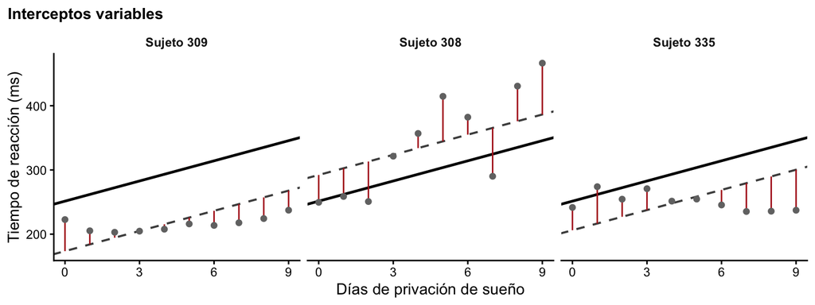

La línea continua es lo que el modelo estima para el participante medio. Las discontinuas, lo que estima para cada participante. Los segmentos rojos son los residuos: la distancia de cada dato a la recta de su participante. Con interceptos variables, cada participante tiene su recta, más alta o más baja, pero todas con la misma pendiente que la poblacional.

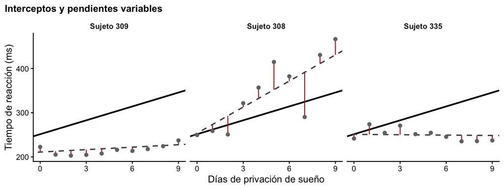

Con pendientes variables, cada recta sigue a su participante y los residuos se encogen.

## Notación matemática

Modelo de interceptos variables:

$$y = \alpha + {\color{firebrick} u_j} + \beta \cdot \text{días} + \varepsilon, \qquad {\color{firebrick} u_j \sim N(0, \tau_\alpha^2)}, \qquad \varepsilon \sim N(0, \sigma^2)$$

**Cómo se leen.**  
$\alpha$ alfa, $\beta$ beta: intercepto y pendiente.  
$u_j$ “u sub jota”, $v_j$ “uve sub jota”: desviaciones del participante $j$.  
$\tau$ tau: su desviación típica ($\tau_\alpha$ interceptos, $\tau_\beta$ pendientes).  
$\varepsilon$ épsilon: residuo.  
$\sigma$ sigma: su desviación típica.

Modelo de interceptos y pendientes variables:

$$y = \alpha + u_j + (\beta + {\color{firebrick} v_j}) \cdot \text{días} + \varepsilon, \quad u_j \sim N(0, \tau_\alpha^2), \quad {\color{firebrick} v_j \sim N(0, \tau_\beta^2)}, \quad \varepsilon \sim N(0, \sigma^2)$$

Es la recta de siempre, $\alpha$ y $\beta$, con una novedad: el subíndice $j$, que aquí es el participante. $u_j$ es cuánto se aparta el intercepto del participante $j$ del intercepto general: su tiempo de reacción descansado, por encima o por debajo de la media. En la segunda ecuación también la pendiente tiene su desviación, $v_j$: cada participante tiene su propio efecto de la falta de sueño. Las desviaciones salen de una normal centrada en cero, y lo que el modelo estima es su desviación típica, $\tau$.

## Notación de R

Modelo de interceptos variables:

`Reaction ~ 1 + Days + (1|Subject)`

Modelo de interceptos y pendientes variables:

`Reaction ~ 1 + Days + (1 + Days|Subject)`

Cuando se habla de un modelo de pendientes variables se da por hecho que también tiene interceptos variables: si se deja variar la pendiente, se deja variar el intercepto.

Lo que va a la izquierda de la barra varía según lo que va a la derecha. `(1|Subject)` se lee “un intercepto distinto para cada participante”: el `1` es el intercepto. `(1 + Days|Subject)`, intercepto y pendiente de los días distintos para cada participante.

# Qué estima el modelo de verdad

Los dieciocho participantes con sus diez días, modelados de tres maneras:

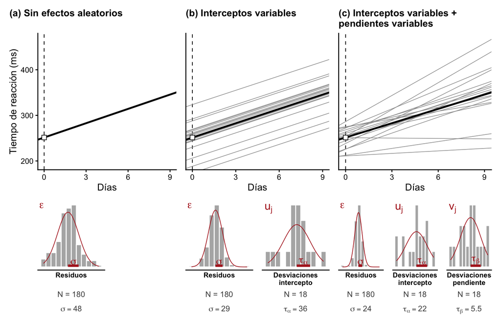

En (a), la regresión lineal de siempre: un solo término de error, el histograma de los 180 residuos. El modelo no sabe que muchos de esos residuos están conectados, porque vienen de solo 18 personas. En (b), cada participante tiene su propia recta, paralela a la poblacional: una **desviación**, $u_j$, que dice cuánto se separa su intercepto del intercepto general, positiva hacia arriba y negativa hacia abajo. El histograma de abajo tiene 18 valores, no 180. En (c), otras 18 desviaciones, $v_j$, ahora respecto a la pendiente general: si la pendiente media es 10 ms por día y un participante tiene 20, su desviación es 10. Y los residuos siguen ahí en los tres modelos, cada vez más estrechos: lo que en (a) era todo error, en (b) y (c) se reparte entre las personas.

Y lo importante: el modelo mixto **no estima un parámetro por participante**. Dejar variar los interceptos añade **un solo término** al modelo: la desviación típica de esas 18 desviaciones, $\tau_\alpha$. Dejar variar las pendientes añade otro, $\tau_\beta$. Con 180 participantes habría los mismos términos, y los mismos histogramas abajo.

## Cómo leer la salida de `lme4`

```r
# Ajustar el modelo de interceptos y pendientes variables
sleep_model_slopes <- lmer(
  formula = Reaction ~ 1 + Days + (1 + Days | Subject),
  data = sleep
)
summary(sleep_model_slopes)
```

```
Linear mixed model fit by REML ['lmerMod']
Formula: Reaction ~ 1 + Days + (1 + Days | Subject)
   Data: sleep

REML criterion at convergence: 1743.6

Scaled residuals:
    Min      1Q  Median      3Q     Max
-3.9536 -0.4634  0.0231  0.4634  5.1793

Random effects:
 Groups   Name        Variance Std.Dev. Corr
 Subject  (Intercept) 612.10   24.741
          Days         35.07    5.922   0.07
 Residual             654.94   25.592
Number of obs: 180, groups:  Subject, 18

Fixed effects:
            Estimate Std. Error t value
(Intercept)  251.405      6.825  36.838
Days          10.467      1.546   6.771

Correlation of Fixed Effects:
     (Intr)
Days -0.138
```

**La salida, en la ecuación.**

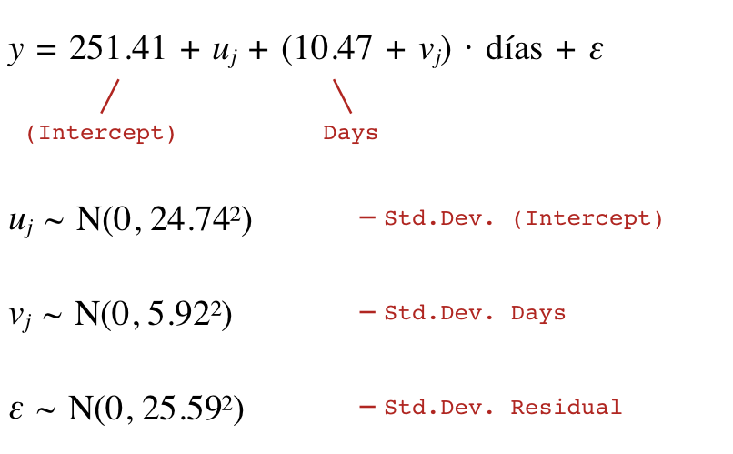

Abajo, *Fixed effects*, la tabla de coeficientes de siempre: $\alpha$, un tiempo de reacción de 251 ms el día 0, y $\beta$, 10.5 ms más por cada día sin dormir. Arriba, *Random effects*: cada desviación típica es un parámetro del modelo. $\tau_\alpha$, 25 ms, es la variación entre personas alrededor de esos 251 ms. Vale la regla del 68 % y el 95 %: se espera que el 68 % de los participantes tengan su tiempo de base entre 227 y 276 ms, y el 95 % entre 202 y 301 ms. $\tau_\beta$, 5.9 ms por día, dice que el 68 % de los participantes empeoran entre 4.5 y 16.4 ms por día. *Residual* es $\sigma$, 26 ms: lo que queda dentro de cada persona. Y *Corr* es la correlación entre $u_j$ y $v_j$, un parámetro más, que aquí es 0.07: la siguiente sección explica qué significa.

Las desviaciones de cada participante, $u_j$ y $v_j$, se piden con `ranef()`:

```r
ranef(sleep_model_slopes)
```

```
$Subject
    (Intercept)        Days
308   2.2585510   9.1989758
309 -40.3987381  -8.6196806
310 -38.9604090  -5.4488565
330  23.6906196  -4.8143503
331  22.2603126  -3.0699116
332   9.0395679  -0.2721770
333  16.8405086  -0.2236361
334  -7.2326151   1.0745816
335  -0.3336684 -10.7521652
337  34.8904868   8.6282652
349 -25.2102286   1.1734322
350 -13.0700342   6.6142178
351   4.5778642  -3.0152621
352  20.8636782   3.5360011
369   3.2754656   0.8722149
370 -25.6129993   4.8224850
371   0.8070461  -0.9881562
372  12.3145921   1.2840221

with conditional variances for "Subject"
```

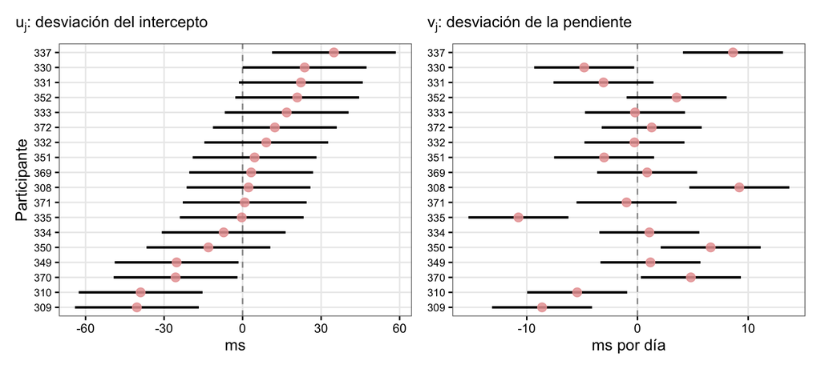

Cada punto es un participante y el segmento, su intervalo: la desviación no se conoce con exactitud, se estima. Los intervalos que cruzan el cero son participantes que no se distinguen del promedio.

Y `coef()` las suma al intercepto y la pendiente generales, $\alpha + u_j$ y $\beta + v_j$: el intercepto y la pendiente de cada participante, las rectas grises de las figuras.

```r
coef(sleep_model_slopes)
```

```
$Subject
    (Intercept)       Days
308    253.6637 19.6662617
309    211.0064  1.8476053
310    212.4447  5.0184295
330    275.0957  5.6529356
331    273.6654  7.3973743
332    260.4447 10.1951090
333    268.2456 10.2436499
334    244.1725 11.5418676
335    251.0714 -0.2848792
337    286.2956 19.0955511
349    226.1949 11.6407181
350    238.3351 17.0815038
351    255.9830  7.4520239
352    272.2688 14.0032871
369    254.6806 11.3395008
370    225.7921 15.2897709
371    252.2122  9.4791297
372    263.7197 11.7513080

attr(,"class")
[1] "coef.mer"
```

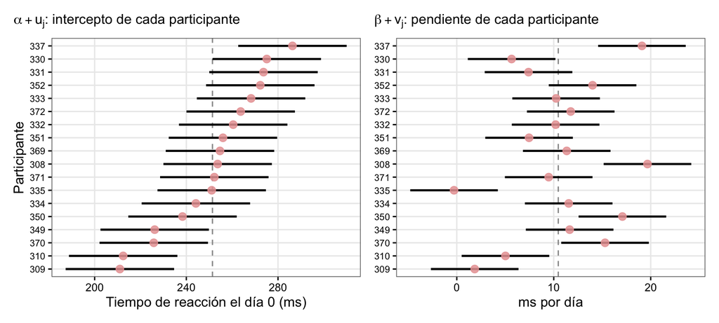

## La correlación entre interceptos y pendientes

*Corr* no es un detalle: dice algo de los datos y puede ser interesante en sí.

> Un ejemplo con datos inventados: Se mide la precisión de cada participante en una tarea, sin y con una tarea de interferencia, un distractor. Si la tarea es demasiado fácil, la interferencia puede afectar poco, y puede pasar que solo a quienes ya les costaba la tarea les afecte de verdad: un **efecto techo**, los demás no tienen margen para empeorar.

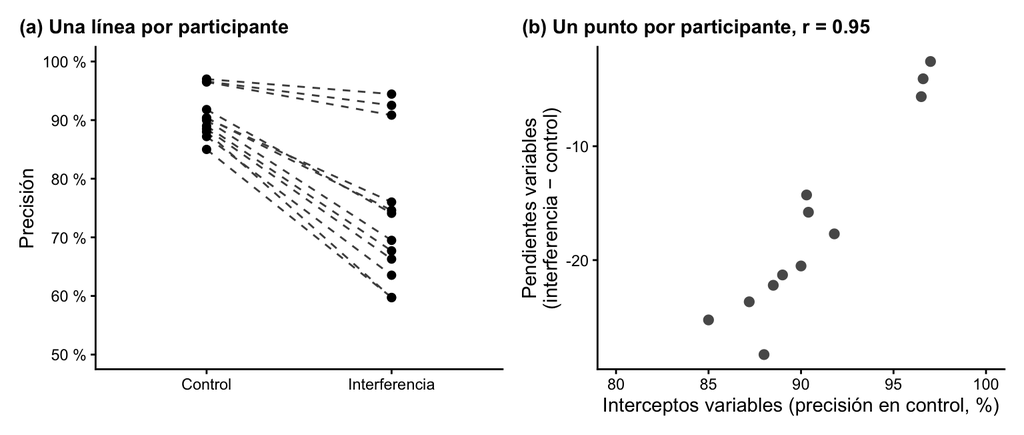

En (a), una línea por participante: quienes mejor rinden en control apenas bajan con la interferencia, y quienes peor rinden bajan mucho. En (b), el intercepto de cada participante, su precisión en control, frente a su pendiente, cuánto baja: la correlación es positiva, un intercepto alto va con una pendiente cercana a cero. Eso es lo que *Corr* resume en un número.

En `sleepstudy` la correlación es 0.07, casi nula: empezar más lento o más rápido no dice nada de cuánto empeora cada uno. Sería negativa si quienes empiezan más lentos empeorasen menos.

# La notación de `lme4`

Solo la parte aleatoria de la fórmula. Lo que va a la izquierda de la barra vertical varía según el factor que va a la derecha; `x` es un efecto fijo cualquiera:

| Corto | Explícito | Qué estima |
| --- | --- | --- |
| `(1\|ppt)` | `(1\|ppt)` | interceptos variables por participante |
| `(x\|ppt)` | `(1 + x\|ppt)` | interceptos y pendientes de `x` variables, con su correlación |
| `(x\|\|ppt)` | `(1 + x\|\|ppt)` o `(1\|ppt) + (0 + x\|ppt)` | interceptos y pendientes variables, sin la correlación |
| `(1\|camada/cria)` | `(1\|camada) + (1\|camada:cria)` | interceptos variables por camada y por cría dentro de camada (anidado) |

> La notación engaña por lo concisa: `(A * B | ppt)` estima diez parámetros, cuatro desviaciones típicas y seis correlaciones. Para quitar las correlaciones se separan los términos: `(1|ppt) + (0 + A|ppt) + (0 + B|ppt) + (0 + A:B|ppt)`. El `0` significa “sin intercepto”.

# Qué pendientes variables incluir

Omitir una pendiente variable importante infla los falsos positivos (Schielzeth y Forstmeier, 2009).

Dos preguntas, en este orden:

1. **¿Se puede?** ¿Varía la variable dentro de cada persona, o dentro de cada ítem? Solo entonces hay una pendiente que estimar.
2. **¿Tiene sentido?** ¿Hay razones para pensar que el efecto cambia de una persona a otra, o de un ítem a otro?

En `sleepstudy` la respuesta es sencilla: los días varían dentro de cada persona, así que se puede, y es razonable que la falta de sueño no afecte a todos igual: `(1 + Days|Subject)`.

Si además tuviéramos la edad de cada participante, podría entrar como efecto fijo, pero no como pendiente variable: en diez días cada persona tiene una sola edad, así que la edad no varía dentro de la persona. En un estudio longitudinal, con las mismas personas medidas durante años, la edad sí varía dentro de cada persona y la pendiente se podría estimar: `(1 + edad|participante)`.